# Infosys VS Tcs (EDA)!

[figure not shown]

# Meta Data:

- **Date:** Represents the current date of trade.
- **Open:** Represents the price at which the financial security opens in the market when trading begins.
- **High:** Represents the highest price that a stock trades in that day.
- **Low:** Represents the lowest price that a stock trades in that day.
- **Close:** Represents a reference to the end of a trading session in the financial markets when the markets close for the day.
- **Adj Close:** Adjusted closing price refers to the price of the stock after paying off the dividends.
- **Volume:** Represents the total number of shares that have been bought or sold during the trading day.

# Report Contains:

1. Import Library
2. TCS data  
   2.1 (TCS) Dataset information  
   2.2 (TCS) Number of null values in dataset  
   2.3 (TCS) Dataset statistical information
3. INFOSYS data  
   3.1 (INFY) Dataset information  
   3.2 (INFY) Number of null values in dataset  
   3.3 (INFY) Dataset statistical information
4. Comparison Analysis and EDA  
   4.1 Calculate stocks Return (in %)  
   4.2 Price Comparison both of the company  
   4.3 Return rate Comparison both of the company  
   4.5 Volume Comparsion for both stocks  
   4.6 Check fluctuation on daily basis for both stock  
   4.7 Last 50 days trend of both stocks side by side

# ⚫ Import Library

```python
import pandas as pd
import numpy as np
import matplotlib.pyplot as plt
import seaborn as sns
import mplfinance as mpl
# pip install --upgrade mplfinance
```

# 📙 TCS data

```python
tcs = pd.read_csv('TCS.NS.csv', index_col='Date', parse_dates=True)
tcs.head(10)
```

| Date | Open | High | Low | Close | Adj Close | Volume |
| --- | --- | --- | --- | --- | --- | --- |
| 2017-11-02 | 1304.250000 | 1337.000000 | 1303.375000 | 1313.074951 | 1199.349854 | 1468422 |
| 2017-11-03 | 1316.199951 | 1318.349976 | 1301.400024 | 1310.050049 | 1196.586670 | 666886 |
| 2017-11-06 | 1310.000000 | 1335.900024 | 1305.875000 | 1332.775024 | 1217.343750 | 1377000 |
| 2017-11-07 | 1335.000000 | 1384.000000 | 1333.025024 | 1355.025024 | 1237.666748 | 2696892 |
| 2017-11-08 | 1361.500000 | 1379.500000 | 1359.125000 | 1367.500000 | 1249.061035 | 1402252 |
| 2017-11-09 | 1375.000000 | 1375.000000 | 1359.650024 | 1368.199951 | 1249.700439 | 1152432 |
| 2017-11-10 | 1361.099976 | 1363.000000 | 1346.675049 | 1354.375000 | 1237.072998 | 1356566 |
| 2017-11-13 | 1351.025024 | 1388.699951 | 1351.025024 | 1379.474976 | 1259.998901 | 1496996 |
| 2017-11-14 | 1378.275024 | 1378.275024 | 1353.750000 | 1357.300049 | 1239.744385 | 1657252 |
| 2017-11-15 | 1353.000000 | 1377.500000 | 1350.675049 | 1352.650024 | 1235.497314 | 6670834 |

.

# ⚫ (TCS) Dataset information

```python
tcs.info()
```

```
<class 'pandas.core.frame.DataFrame'>
DatetimeIndex: 1235 entries, 2017-11-02 to 2022-11-01
Data columns (total 6 columns):
 #   Column     Non-Null Count  Dtype
---  ------     --------------  -----
 0   Open       1235 non-null   float64
 1   High       1235 non-null   float64
 2   Low        1235 non-null   float64
 3   Close      1235 non-null   float64
 4   Adj Close  1235 non-null   float64
 5   Volume     1235 non-null   int64
dtypes: float64(5), int64(1)
memory usage: 67.5 KB
```

.

# ⚫ (TCS) Number of null values in dataset

```python
tcs.isnull().sum()
```

```
Open         0
High         0
Low          0
Close        0
Adj Close    0
Volume       0
dtype: int64
```

.

# ⚫ (TCS) Dataset statistical information

```python
tcs.describe()
```

|  | Open | High | Low | Close | Adj Close | Volume |
| --- | --- | --- | --- | --- | --- | --- |
| count | 1235.000000 | 1235.000000 | 1235.000000 | 1235.000000 | 1235.000000 | 1.235000e+03 |
| mean | 2517.772529 | 2543.625319 | 2489.836221 | 2516.272792 | 2428.493448 | 3.127995e+06 |
| std | 734.088662 | 738.030266 | 727.998626 | 732.955559 | 766.403293 | 3.075381e+06 |
| min | 1268.500000 | 1292.224976 | 1247.175049 | 1272.800049 | 1162.562744 | 1.445300e+05 |
| 25% | 1984.000000 | 2002.000000 | 1962.525024 | 1983.099976 | 1847.940429 | 1.928873e+06 |
| 50% | 2217.850098 | 2244.500000 | 2194.199951 | 2215.600098 | 2107.700684 | 2.611493e+06 |
| 75% | 3198.474976 | 3224.924926 | 3162.075074 | 3195.474976 | 3150.350463 | 3.573045e+06 |
| max | 4033.949951 | 4043.000000 | 3980.000000 | 4019.149902 | 3964.502686 | 8.806715e+07 |

.

# 📙 INFOSYS data

```python
infy = pd.read_csv('INFY.NS.csv', index_col='Date', parse_dates=True)
infy.head(10)
```

| Date | Open | High | Low | Close | Adj Close | Volume |
| --- | --- | --- | --- | --- | --- | --- |
| 2017-11-02 | 461.524994 | 463.000000 | 460.000000 | 461.450012 | 406.673004 | 4686138 |
| 2017-11-03 | 458.500000 | 464.950012 | 458.475006 | 463.325012 | 408.325439 | 3699086 |
| 2017-11-06 | 461.575012 | 467.500000 | 461.325012 | 464.350006 | 409.228668 | 5066534 |
| 2017-11-07 | 463.125000 | 480.000000 | 462.924988 | 477.750000 | 421.038086 | 13442820 |
| 2017-11-08 | 480.125000 | 480.924988 | 473.750000 | 476.149994 | 419.627991 | 5369994 |
| 2017-11-09 | 476.500000 | 481.500000 | 474.125000 | 477.250000 | 420.597412 | 4723232 |
| 2017-11-10 | 479.399994 | 482.174988 | 475.000000 | 481.024994 | 423.924316 | 6589428 |
| 2017-11-13 | 481.024994 | 484.700012 | 474.674988 | 475.975006 | 419.473785 | 5021216 |
| 2017-11-14 | 475.975006 | 477.424988 | 471.625000 | 474.549988 | 418.217926 | 5733710 |
| 2017-11-15 | 472.575012 | 476.750000 | 472.250000 | 475.899994 | 419.407684 | 7023516 |

.

# ⚫ (INFY) Dataset information

```python
infy.info()
```

```
<class 'pandas.core.frame.DataFrame'>
DatetimeIndex: 1235 entries, 2017-11-02 to 2022-11-01
Data columns (total 6 columns):
 #   Column     Non-Null Count  Dtype
---  ------     --------------  -----
 0   Open       1235 non-null   float64
 1   High       1235 non-null   float64
 2   Low        1235 non-null   float64
 3   Close      1235 non-null   float64
 4   Adj Close  1235 non-null   float64
 5   Volume     1235 non-null   int64
dtypes: float64(5), int64(1)
memory usage: 67.5 KB
```

.

# ⚫ (INFY) Number of null values in dataset

```python
infy.isnull().sum()
```

```
Open         0
High         0
Low          0
Close        0
Adj Close    0
Volume       0
dtype: int64
```

.

# ⚫ (INFY) Dataset statistical information

```python
infy.describe()
```

|  | Open | High | Low | Close | Adj Close | Volume |
| --- | --- | --- | --- | --- | --- | --- |
| count | 1235.000000 | 1235.000000 | 1235.000000 | 1235.000000 | 1235.000000 | 1.235000e+03 |
| mean | 1040.153726 | 1051.354049 | 1029.087085 | 1040.137409 | 988.241594 | 8.488027e+06 |
| std | 433.301951 | 436.597649 | 429.126905 | 432.849813 | 443.829212 | 5.944440e+06 |
| min | 458.500000 | 463.000000 | 458.475006 | 461.450012 | 406.673004 | 4.834070e+05 |
| 25% | 690.325012 | 699.000000 | 682.662476 | 691.174988 | 627.743866 | 5.362184e+06 |
| 50% | 788.000000 | 797.000000 | 782.049988 | 789.549988 | 728.917236 | 7.016424e+06 |
| 75% | 1453.500000 | 1467.799988 | 1437.725036 | 1451.824951 | 1430.209045 | 9.723727e+06 |
| max | 1938.550049 | 1953.900024 | 1930.500000 | 1939.500000 | 1898.427979 | 9.043211e+07 |

.

# 📉Comparison Analysis and EDA📈

# ⚫ Calculate stocks Return (in %)

### Return = (Close-Open)/Open

### Return of daily basis for TCS

```python
tcs['Return'] = (tcs.Close - tcs.Open)/tcs.Open
tcs.head()
```

| Date | Open | High | Low | Close | Adj Close | Volume | Return |
| --- | --- | --- | --- | --- | --- | --- | --- |
| 2017-11-02 | 1304.250000 | 1337.000000 | 1303.375000 | 1313.074951 | 1199.349854 | 1468422 | 0.006766 |
| 2017-11-03 | 1316.199951 | 1318.349976 | 1301.400024 | 1310.050049 | 1196.586670 | 666886 | -0.004672 |
| 2017-11-06 | 1310.000000 | 1335.900024 | 1305.875000 | 1332.775024 | 1217.343750 | 1377000 | 0.017386 |
| 2017-11-07 | 1335.000000 | 1384.000000 | 1333.025024 | 1355.025024 | 1237.666748 | 2696892 | 0.015000 |
| 2017-11-08 | 1361.500000 | 1379.500000 | 1359.125000 | 1367.500000 | 1249.061035 | 1402252 | 0.004407 |

### Return of daily basis for INFOSYS

```python
infy['Return'] = (infy.Close - infy.Open)/infy.Open
infy.head()
```

| Date | Open | High | Low | Close | Adj Close | Volume | Return |
| --- | --- | --- | --- | --- | --- | --- | --- |
| 2017-11-02 | 461.524994 | 463.000000 | 460.000000 | 461.450012 | 406.673004 | 4686138 | -0.000162 |
| 2017-11-03 | 458.500000 | 464.950012 | 458.475006 | 463.325012 | 408.325439 | 3699086 | 0.010523 |
| 2017-11-06 | 461.575012 | 467.500000 | 461.325012 | 464.350006 | 409.228668 | 5066534 | 0.006012 |
| 2017-11-07 | 463.125000 | 480.000000 | 462.924988 | 477.750000 | 421.038086 | 13442820 | 0.031579 |
| 2017-11-08 | 480.125000 | 480.924988 | 473.750000 | 476.149994 | 419.627991 | 5369994 | -0.008279 |

.

# ⚫ Price Comparison both of the company

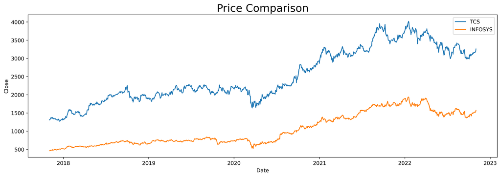

```python
plt.figure(figsize=(16,5), dpi=400)
plt.title('Price Comparison', size=20)
sns.lineplot(data=tcs, x=tcs.index, y='Close', label='TCS')
sns.lineplot(data=infy, x=infy.index, y='Close', label='INFOSYS')
plt.show()
```

### Conclusion: TCS stocks are all time on hike than INFOSYS stocks.

.

# ⚫ Return rate Comparison both of the company

```python
tcs_return = []
x = 0
for i in tcs.Return:
    x += i
    tcs_return.append(x)
```

```python
infy_return = []
x = 0
for i in infy.Return:
    x += i
    infy_return.append(x)
```

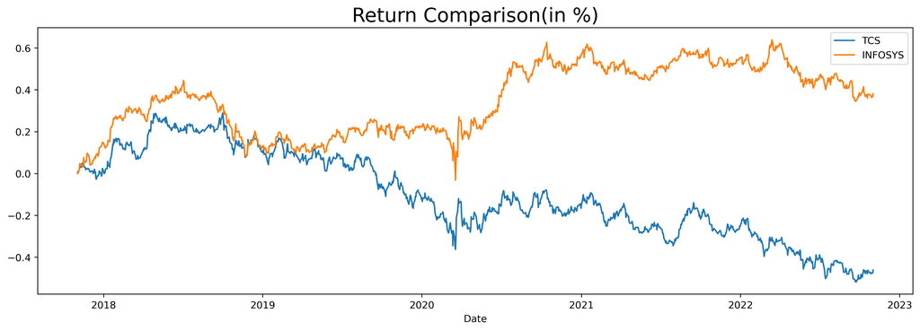

```python
plt.figure(figsize=(16,5), dpi=400)
plt.title('Return Comparison(in %)', size=20)
sns.lineplot(data=tcs, x=tcs.index, y=tcs_return, label='TCS')
sns.lineplot(data=infy, x=infy.index, y=infy_return, label='INFOSYS')
plt.show()
```

### Conclusion: TCS stocks return rate is less than INFOSYS stocks.

.

# ⚫ Volume Comparsion for both stocks

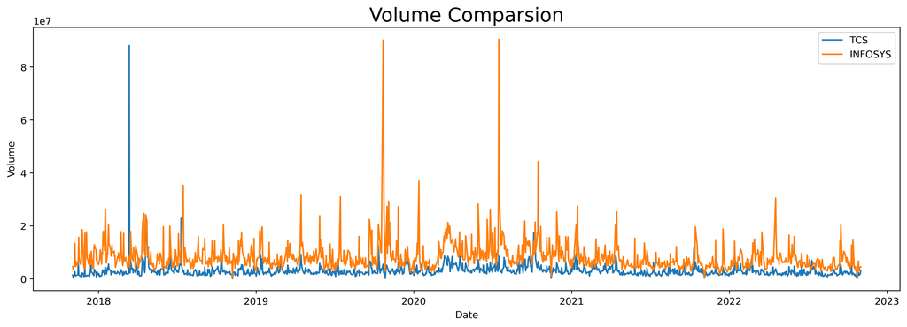

```python
plt.figure(figsize=(16,5), dpi=400)
plt.title('Volume Comparsion', size=20)
sns.lineplot(data=tcs, x=tcs.index, y='Volume', label='TCS')
sns.lineplot(data=infy, x=infy.index, y='Volume', label='INFOSYS')
plt.show()
```

### Conclusion: Availability of INFOSYS stocks is more than TCS stocks.

.

# ⚫ Check fluctuation on daily basis for both stock

### Fluctuation = difference of High and Low

### Fluctuation of daily basis for TCS

```python
tcs['Fluctuation'] = tcs.High - tcs.Low
tcs.head()
```

| Date | Open | High | Low | Close | Adj Close | Volume | Return | Fluctuation |
| --- | --- | --- | --- | --- | --- | --- | --- | --- |
| 2017-11-02 | 1304.250000 | 1337.000000 | 1303.375000 | 1313.074951 | 1199.349854 | 1468422 | 0.006766 | 33.625000 |
| 2017-11-03 | 1316.199951 | 1318.349976 | 1301.400024 | 1310.050049 | 1196.586670 | 666886 | -0.004672 | 16.949952 |
| 2017-11-06 | 1310.000000 | 1335.900024 | 1305.875000 | 1332.775024 | 1217.343750 | 1377000 | 0.017386 | 30.025024 |
| 2017-11-07 | 1335.000000 | 1384.000000 | 1333.025024 | 1355.025024 | 1237.666748 | 2696892 | 0.015000 | 50.974976 |
| 2017-11-08 | 1361.500000 | 1379.500000 | 1359.125000 | 1367.500000 | 1249.061035 | 1402252 | 0.004407 | 20.375000 |

### Fluctuation of daily basis for INFOSYS

```python
infy['Fluctuation'] = infy.High - infy.Low
infy.head()
```

| Date | Open | High | Low | Close | Adj Close | Volume | Return | Fluctuation |
| --- | --- | --- | --- | --- | --- | --- | --- | --- |
| 2017-11-02 | 461.524994 | 463.000000 | 460.000000 | 461.450012 | 406.673004 | 4686138 | -0.000162 | 3.000000 |
| 2017-11-03 | 458.500000 | 464.950012 | 458.475006 | 463.325012 | 408.325439 | 3699086 | 0.010523 | 6.475006 |
| 2017-11-06 | 461.575012 | 467.500000 | 461.325012 | 464.350006 | 409.228668 | 5066534 | 0.006012 | 6.174988 |
| 2017-11-07 | 463.125000 | 480.000000 | 462.924988 | 477.750000 | 421.038086 | 13442820 | 0.031579 | 17.075012 |
| 2017-11-08 | 480.125000 | 480.924988 | 473.750000 | 476.149994 | 419.627991 | 5369994 | -0.008279 | 7.174988 |

### Comparison of Fluctuation

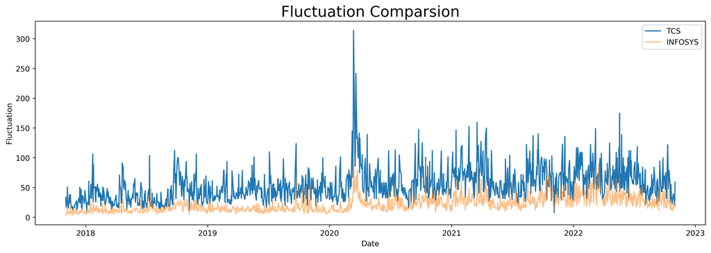

```python
plt.figure(figsize=(16,5), dpi=400)
plt.title('Fluctuation Comparsion', size=20)
sns.lineplot(data=tcs, x=tcs.index, y='Fluctuation', label='TCS')
sns.lineplot(data=infy, x=infy.index, y='Fluctuation', label='INFOSYS', alpha=0.5)
plt.show()
```

### Conclusion: Fluctuation rate of TCS stocks is higher than INFOSYS stocks.

.

# ⚫ Last 50 days trend of both stocks side by side

### Last 50 days data of TCS stocks.

```python
data_tcs = tcs[['Open','High','Low','Close']].tail(50)
```

### Last 50 days data of INFOSYS stocks.

```python
data_infy = infy[['Open','High','Low','Close']].tail(50)
```

# Explaination of Candlestick chart!

[figure not shown]

### Side by Side stocks Comparison

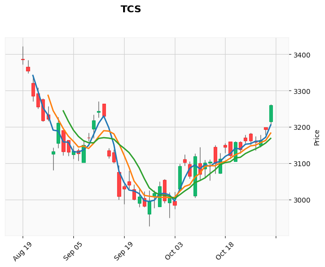

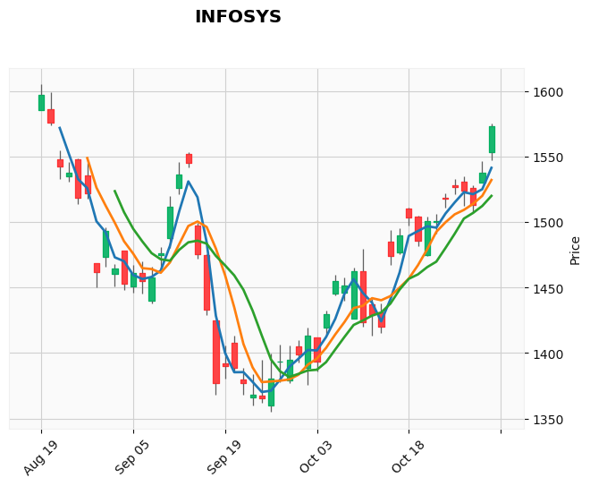

```python
mpl.plot(data_tcs, type='candle', mav=(3,6,9), style='yahoo', title='TCS')
mpl.plot(data_infy, type='candle', mav=(3,6,9), style='yahoo', title='INFOSYS')
```